# Using Branchpointer for annotation of intronic human splicing branchpoints

Beth Signal

2018-03-06

#### Package version: branchpointer

# 1 Introduction

The spliceosome mediates the formation of an intron lariat though inter-action between the 5’ splice site and branchpoint (Will and Luhrmann, 2011). A subsequent reaction at the 3’ SS then removes the intron lariat, producing a spliced RNA product. Mapping of branchpoints generally requires sequencing of the intron lariat following cDNA synthesis (Gao et al., 2008; Taggart et al., 2012). However, intron lariats are rapidly de-branched and degraded, and much less abundant than the spliced RNA, resulting in the poor recovery of elements using sequencing. Most recently, Mercer et al. (2015) employed a targeted sequencing approach to identify 59,359 branchpoints in 17.4% of annotated human gene introns. Whilst this constituted the largest annotation to date, the identification of branchpoints was restricted to highly-expressed genes with sufficient sequence coverage.

To address this limitation, and expand branchpoint annotations across the human genome, we have developed a machine-learning based model of branchpoints trained with this empirical annotation (Signal et al., 2017). This model requires only genomic sequence and exon annotations, and exhibits no discernible bias to gene type or expression, and can be applied using the R package, branchpointer. Aberrant splicing is known to lead to many human diseases (Singh and Cooper, 2012), however prediction of intronic variant effects have been typically limited to splice site alterations (McLaren et al., 2016; Wang et al., 2010). Therefore, in addition to annotation of branchpoints, branchpointer allows users to assess the effects of intronic mutations on branchpoint architecture.

Gao,K. et al. (2008) Human branch point consensus sequence is yUnAy. Nucleic Acids Res., 36, 2257–67.

McLaren,W. et al. (2016) The Ensembl Variant Effect Predictor. Genome Biol., 17, 122.

Mercer,T.R. et al. (2015) Genome-wide discovery of human splicing branchpoints. Genome Res., 25, 290–303.

Signal,B. et al. (2017) Machine learning annotation of human branchpoints. Bioinformatics, 1, 8.

Singh,R.K. and Cooper,T.A. (2012) Pre-mRNA splicing in disease and therapeutics. Trends Mol. Med., 18, 472–482.

Taggart,A.J. et al. (2012) Large-scale mapping of branchpoints in human pre-mRNA transcripts in vivo. Nat. Struct. Mol. Biol., 19, 719–21.

Wang,K. et al. (2010) ANNOVAR: functional annotation of genetic variants from high-throughput sequencing data. Nucleic Acids Res., 38, e164.

Will,C.L. and Luhrmann,R. (2011) Spliceosome structure and function. Cold Spring Harb. Perspect. Biol., 3, a003707.

# 2 Preparation

## 2.1 Download genome annotations

Branchpointer requires a genome annotation GTF file for branchpoint annotation. We will be using the GENCODE annotation (http://www.gencodegenes.org/releases/current.html) as an example, although others and custom annotations can be used.

Create or move to a working directory where these files can be stored. Note that GTFs can be large files (over 1GB) when uncompressed.

```bash
wget ftp://ftp.sanger.ac.uk/pub/gencode/Gencode_human/release_26/gencode.v26.annotation.gtf.gz
```

branchpointer requires either a BSGenome object, or a genome .fa file for sequence retrieval. The genome must correspond to the gtf used – i.e. gencodev26 uses GRCh38.

load a (BSGenome)[http://bioconductor.org/packages/BSgenome/]:

```r
library(BSgenome.Hsapiens.UCSC.hg38)
g <- BSgenome.Hsapiens.UCSC.hg38::BSgenome.Hsapiens.UCSC.hg38
```

or download .fa:

```bash
wget ftp://ftp.sanger.ac.uk/pub/gencode/Gencode_human/release_26/GRCh38.primary_assembly.genome.fa.gz
gunzip GRCh38.primary_assembly.genome.fa.gz
```

## 2.2 Read in exon annotations

Start by loading branchpointer.

```r
library(branchpointer)
```

gtfToExons will generate an exon annotation GRanges object from a gtf. To load in the gtf downloaded from the preparation section:

```r
exons <- gtfToExons("gencode.v26.annotation.gtf")
```

We will load in a small gtf from the package data for the following examples.

```r
smallExons <- system.file("extdata","gencode.v26.annotation.small.gtf",
                          package = "branchpointer")
exons <- gtfToExons(smallExons)
```

# 3 Branchpoint annotations in intronic regions

## 3.1 Read query and calculate location attributes

Query regions must contain a branchpoint window - that is the region located at -18 to -44 from the 3’ splice site. Each region given will be treated as only one query, and associated with the closest 3’ exon. To cover multiple 3’exons, please provide branchpointer with separate region queries. For known regions, queries can be supplied as a table with the following formatting:

```r
queryIntronFile <- system.file("extdata","intron_example.txt",
                               package = "branchpointer")
queryIntronTable <- read.delim(queryIntronFile)
head(queryIntronTable)
```

```
##             id chromosome    start      end strand
## 1 BRCA1_intron      chr17 43045820 43045846      -
## 2 BRCA2_intron      chr13 32346783 32346809      +
```

Query files can be read into branchpointer using readQueryFile(), and location information retrieved for these sequences:

```r
queryIntron <- readQueryFile(queryIntronFile,
                             queryType = "region",
                             exons = exons)
head(queryIntron)
```

```
## GRanges object with 2 ranges and 6 metadata columns:
##       seqnames               ranges strand |           id to_3prime
##          <Rle>            <IRanges>  <Rle> |  <character> <numeric>
##   [1]    chr17 [43045820, 43045846]      - | BRCA1_intron        18
##   [2]    chr13 [32346783, 32346809]      + | BRCA2_intron        18
##       to_5prime same_gene       exon_3prime       exon_5prime
##       <numeric> <logical>       <character>       <character>
##   [1]      1823      TRUE ENSE00001814242.1 ENSE00003687053.1
##   [2]      2156      TRUE ENSE00000939171.1 ENSE00003753873.1
##   -------
##   seqinfo: 2 sequences from an unspecified genome; no seqlengths
```

Alternatively, to generate branchpoint window region queries by from the gtf annotation, the exon object can be used:

Note that when searching for genes, transcripts, or exons, the ids used must be in the same format as in the annotation file (i.e. ENSG00000XXXXXX.X, ENST00000XXXXXX.X, ENSE00000XXXXXX.X). If you are unsure of an id, aliases can typically be found through ensembl (ensembl.org), or through a biomaRt query.

```r
queryIntronFromGTF <- makeBranchpointWindowForExons("ENSE00000939171.1",
                                                    idType = "exon_id",
                                                    exons = exons)
head(queryIntronFromGTF)
```

```
## GRanges object with 1 range and 12 metadata columns:
##       seqnames               ranges strand |            gene_id
##          <Rle>            <IRanges>  <Rle> |        <character>
##   [1]    chr13 [32346783, 32346809]      + | ENSG00000139618.14
##            gene_type     transcript_id transcript_type           exon_id
##          <character>       <character>     <character>       <character>
##   [1] protein_coding ENST00000380152.7  protein_coding ENSE00000939171.1
##       exon_number to_3prime to_5prime same_gene       exon_3prime
##       <character> <numeric> <integer> <logical>       <character>
##   [1]          13        18      2156      TRUE ENSE00000939171.1
##             exon_5prime                id
##             <character>       <character>
##   [1] ENSE00000939169.1 ENSE00000939171.1
##   -------
##   seqinfo: 7 sequences from an unspecified genome; no seqlengths
```

```r
# for multiple ids:
queryIntronFromGTF <- makeBranchpointWindowForExons(c("ENSE00000939171.1",
                                                      "ENSE00001814242.1"),
                                                    idType = "exon_id",
                                                    exons = exons)
head(queryIntronFromGTF)
```

```
## GRanges object with 2 ranges and 12 metadata columns:
##       seqnames               ranges strand |            gene_id
##          <Rle>            <IRanges>  <Rle> |        <character>
##   [1]    chr13 [32346783, 32346809]      + | ENSG00000139618.14
##   [2]    chr17 [43045820, 43045846]      - | ENSG00000012048.20
##            gene_type     transcript_id transcript_type           exon_id
##          <character>       <character>     <character>       <character>
##   [1] protein_coding ENST00000380152.7  protein_coding ENSE00000939171.1
##   [2] protein_coding ENST00000357654.7  protein_coding ENSE00001814242.1
##       exon_number to_3prime to_5prime same_gene       exon_3prime
##       <character> <numeric> <integer> <logical>       <character>
##   [1]          13        18      2156      TRUE ENSE00000939171.1
##   [2]          23        18      1823      TRUE ENSE00001814242.1
##             exon_5prime                id
##             <character>       <character>
##   [1] ENSE00000939169.1 ENSE00000939171.1
##   [2] ENSE00003687053.1 ENSE00001814242.1
##   -------
##   seqinfo: 7 sequences from an unspecified genome; no seqlengths
```

### 3.1.1 Using bedtools with a genome .fa file

During the prediction step, if a BSGenome object is not specified, sequences covering each site +/- 250 nt can be retrieved using bedtools. The absolute location of the bedtools binary must be provided for calls from within R. To find the location of your installed bedtools binary, using the command line type:

```bash
which bedtools
```

## 3.2 Predict branchpoint probabilities

Branchpoint probability scores can now be evaluated using the branchpointer model. This will generate a new GRanges object with a row for each site (of 27) in branchpoint window regions. If a SNP query type is provided (See next section), this will also perform an in silico mutation of the sequence.

We recommend use of the cut-off probability 0.52 to distinguish branchpoints and non-branchpoint sites. U2 binding energy can be used as a measurement of branchpoint strength when the probability score is above the cut-off.

All features required for the model to predict branchpoint probability are contained within the output object, along with the score and U2 binding energy.

```r
branchpointPredictionsIntron <- predictBranchpoints(queryIntron,
                                                    queryType = "region",
                                                    BSgenome = g)
head(branchpointPredictionsIntron)
```

```
## GRanges object with 6 ranges and 31 metadata columns:
##       seqnames               ranges strand |           id to_3prime
##          <Rle>            <IRanges>  <Rle> |  <character> <numeric>
##   [1]    chr17 [43045820, 43045846]      - | BRCA1_intron        18
##   [2]    chr13 [32346783, 32346809]      + | BRCA2_intron        18
##   [3]    chr17 [43045820, 43045846]      - | BRCA1_intron        18
##   [4]    chr13 [32346783, 32346809]      + | BRCA2_intron        18
##   [5]    chr17 [43045820, 43045846]      - | BRCA1_intron        18
##   [6]    chr13 [32346783, 32346809]      + | BRCA2_intron        18
##       to_5prime same_gene       exon_3prime       exon_5prime
##       <numeric> <logical>       <character>       <character>
##   [1]      1823      TRUE ENSE00001814242.1 ENSE00003687053.1
##   [2]      2156      TRUE ENSE00000939171.1 ENSE00003753873.1
##   [3]      1823      TRUE ENSE00001814242.1 ENSE00003687053.1
##   [4]      2156      TRUE ENSE00000939171.1 ENSE00003753873.1
```

[output cut: 44 more lines]

The window scores can be plotted using plotBranchpointWindow(), with optional plots for gene and isoform structure. The main panel displays the probability scores of each site within the branchpoint window. The opacity of the bars is representative of relative U2 binding energy (darker = stronger), and the lower panel shows U2 binding energy for all sites above the provided probability cutoff.

BRCA2 intron (ENSE00000939169.1 - ENSE00000939171.1):

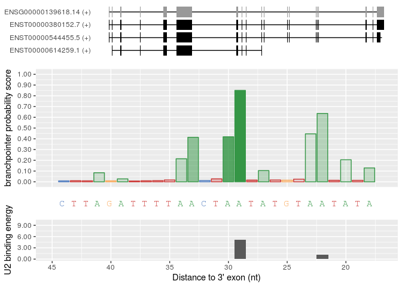

```r
plotBranchpointWindow(queryIntron$id[2],
                      branchpointPredictionsIntron,
                      probabilityCutoff = 0.52,
                      plotMutated = FALSE,
                      plotStructure = TRUE,
                      exons = exons)
```

# 4 Effects of SNPs on branchpoint annotations

In addition to locating branchpoints in intronic windows, branchpointer can be used to evaluate the local effects of SNPs on branchpoints. The general workflow is the same as for annotation of intronic windows, however queryType=“SNP” must be used.

## 4.1 Read query and calculate location attributes

Query SNPs should be located nearby a branchpoint window to have any potential effects on branchpoint architecture SNP queries can be supplied as a table formatted as follows:

```r
querySNPFile <- system.file("extdata","SNP_example.txt",
                            package = "branchpointer")
querySNPTable <- read.delim(querySNPFile)
head(querySNPTable)
```

```
##            id chromosome chrom_start strand ref_allele alt_allele
## 1 rs786205083       chr2    71590178      +          A          G
## 2 rs587776767      chr11     2165787      -          A          T
```

When reading in exceptionally large numbers of SNPs, it is recommended to set `filter = TRUE`. This adds a pre-filtering step which removes any SNPs not located in an intron or 50nt from a 3’ exon.

Each SNP will be associated with the closest 3’ exon. If SNPs are distal from branchpoint windows, the `max_dist` argument will remove any greater than the specified distance. Filtering prior to exon associations can therefore speed up processing in instances where it is unknown if the majority of SNPs fall nearby branchpoint windows.

```r
querySNP <- readQueryFile(querySNPFile,
                          queryType = "SNP",
                          exons = exons,
                          filter = TRUE)
head(querySNP)
```

```
## GRanges object with 2 ranges and 8 metadata columns:
##       seqnames               ranges strand |              id  ref_allele
##          <Rle>            <IRanges>  <Rle> |     <character> <character>
##   [1]     chr2 [71590178, 71590178]      + | rs786205083_pos           A
##   [2]    chr11 [ 2165787,  2165787]      - | rs587776767_neg           A
##        alt_allele to_3prime to_5prime same_gene       exon_3prime
##       <character> <numeric> <numeric> <logical>       <character>
##   [1]           G        33       492      TRUE ENSE00003642866.1
##   [2]           T        24        66      TRUE ENSE00003550033.1
##             exon_5prime
##             <character>
##   [1] ENSE00003663865.1
##   [2] ENSE00001878270.1
##   -------
##   seqinfo: 2 sequences from an unspecified genome; no seqlengths
```

Queries can be provided as stranded or unstranded. In the case of unstranded queries, any value except `"+"` or `"-"` will cause branchpointer to run on both strands.

Alternatively, appropriate attributes can be pulled from biomart when a list of refsnp ids is provided:

```r
library(biomaRt)
mart <- useMart("ENSEMBL_MART_SNP", dataset="hsapiens_snp",host="www.ensembl.org")
querySNP <- makeBranchpointWindowForSNP(c("rs587776767","rs786205083"),
                                        mart.snp = mart,
                                        exons = exons,
                                        filter  = FALSE)
```

By default, all SNPs retrieved will be unstranded, and hence further processing will be done on both strands

## 4.2 Predict branchpoint probabilities

Using a .fa and bedtools:

```r
branchpointPredictionsSNP <- predictBranchpoints(querySNP,
                                        queryType = "SNP",
                                        genome = "GRCh38.primary_assembly.genome.fa",
                                        bedtoolsLocation="/Apps/bedtools2/bin/bedtools")
```

Using a BSgenome:

```r
#for query SNPs
branchpointPredictionsSNP <- predictBranchpoints(querySNP,
                                        queryType = "SNP",
                                        BSgenome = g)
head(branchpointPredictionsSNP)
```

```
## GRanges object with 6 ranges and 33 metadata columns:
##       seqnames               ranges strand |              id  ref_allele
##          <Rle>            <IRanges>  <Rle> |     <character> <character>
##   [1]     chr2 [71590178, 71590178]      + | rs786205083_pos           A
##   [2]    chr11 [ 2165787,  2165787]      - | rs587776767_neg           A
##   [3]     chr2 [71590178, 71590178]      + | rs786205083_pos           A
##   [4]    chr11 [ 2165787,  2165787]      - | rs587776767_neg           A
##   [5]     chr2 [71590178, 71590178]      + | rs786205083_pos           A
##   [6]    chr11 [ 2165787,  2165787]      - | rs587776767_neg           A
##        alt_allele to_3prime to_5prime same_gene       exon_3prime
##       <character> <numeric> <numeric> <logical>       <character>
##   [1]           G        33       492      TRUE ENSE00003642866.1
##   [2]           T        24        66      TRUE ENSE00003550033.1
##   [3]           G        33       492      TRUE ENSE00003642866.1
##   [4]           T        24        66      TRUE ENSE00003550033.1
```

[output cut: 52 more lines]

```r
#to summarise effects:
querySNPSummary <- predictionsToSummary(querySNP,branchpointPredictionsSNP)
head(querySNPSummary)
```

```
## GRanges object with 2 ranges and 19 metadata columns:
##       seqnames               ranges strand |              id  ref_allele
##          <Rle>            <IRanges>  <Rle> |     <character> <character>
##   [1]     chr2 [71590178, 71590178]      + | rs786205083_pos           A
##   [2]    chr11 [ 2165787,  2165787]      - | rs587776767_neg           A
##        alt_allele to_3prime to_5prime same_gene       exon_3prime
##       <character> <numeric> <numeric> <logical>       <character>
##   [1]           G        33       492      TRUE ENSE00003642866.1
##   [2]           T        24        66      TRUE ENSE00003550033.1
##             exon_5prime BP_num_REF BP_num_ALT deleted_n created_n
##             <character>  <numeric>  <numeric> <numeric> <numeric>
##   [1] ENSE00003663865.1          2          1         1         0
##   [2] ENSE00001878270.1          1          0         1         0
##       is_in_window dist_to_BP_REF dist_to_BP_ALT max_prob_REF max_prob_ALT
##          <numeric>      <numeric>      <numeric>    <numeric>    <numeric>
##   [1]            0              0              8    0.9222648    0.5616098
##   [2]            0              2           <NA>    0.9236876    0.4358921
##       max_U2_REF max_U2_ALT
##        <numeric>  <numeric>
##   [1]        2.0        0.5
##   [2]        2.5       <NA>
##   -------
##   seqinfo: 2 sequences from an unspecified genome; no seqlengths
```

The window scores in the reference and alternative sequences can be visualised using plotBranchpointWindow().

rs587776767 in TH intron

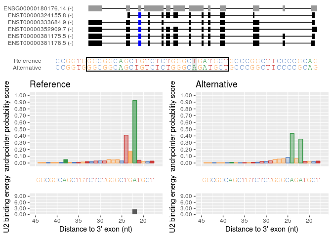

```r
plotBranchpointWindow(querySNP$id[2],
                      branchpointPredictionsSNP,
                      probabilityCutoff = 0.52,
                      plotMutated = TRUE,
                      plotStructure = TRUE,
                      exons = exons)
```

# 5 Effects of deletions, insertions and indels on branchpoint annotations

In addition to locating branchpoints in intronic windows, branchpointer can be used to evaluate the local effects of deletions, insertions and indels on branchpoints. The general workflow is the same as for annotation of intronic windows, however `queryType="indel"` must be used.

## 5.1 Read query and calculate location attributes

Query indels should be located nearby a branchpoint window to have any potential effects on branchpoint architecture SNP queries can be supplied as a table formatted as follows:

```r
queryIndelFile <- system.file("extdata","indel_example.txt",
                            package = "branchpointer")
queryIndelTable <- read.delim(queryIndelFile)
head(queryIndelTable)
```

```
##       id chromosome chrom_start chrom_end strand ref_allele alt_allele
## 1 246119      chr19    11113504  11113512      *  GCGCTGATG      CGGCT
## 2 389807       chr7    98315625  98315626      *          -       TAAT
## 3  45453      chr17    42338842  42338846      *      AAGTA          -
## 4 245526      chr19    11105280  11105281      *          -       CTGA
## 5 406041       chr2    84425613  84425616      *       AAGT          -
## 6  99667       chrX   154354909 154354910      *         GA         TT
```

Branchpointer automatically filters for deletions/insertions and indel event within 50 nt of a 3’ SS. The distance can be changed by altering `maxDist`. Like with SNPs, each event will be associated with the closest 3’ exon.

```r
queryIndel <- readQueryFile(queryIndelFile,
                          queryType = "indel",
                          exons = exons,
                          filter = TRUE)
head(queryIndel)
```

```
## GRanges object with 6 ranges and 9 metadata columns:
##       seqnames                 ranges strand |          id  ref_allele
##          <Rle>              <IRanges>  <Rle> | <character> <character>
##   [1]    chr19 [ 11113504,  11113512]      + |      246119   GCGCTGATG
##   [2]     chr7 [ 98315625,  98315626]      - |      389807           -
##   [3]    chr17 [ 42338842,  42338846]      - |       45453       AAGTA
##   [4]    chr19 [ 11105280,  11105281]      + |      245526           -
##   [5]     chr2 [ 84425613,  84425616]      - |      406041        AAGT
##   [6]     chrX [154354909, 154354910]      - |       99667          GA
##        alt_allele        type to_3prime to_5prime same_gene
##       <character> <character> <numeric> <numeric> <logical>
##   [1]       CGGCT       indel        23        23      TRUE
##   [2]        TAAT   insertion        13      1593      TRUE
##   [3]           -    deletion        30       468      TRUE
##   [4]        CTGA   insertion        26      1012      TRUE
##   [5]           -    deletion        10      5892      TRUE
##   [6]          TT       indel        20      2341      TRUE
##             exon_3prime       exon_5prime
##             <character>       <character>
##   [1] ENSE00003509370.1 ENSE00002572374.1
##   [2] ENSE00003477971.1 ENSE00003483870.1
##   [3] ENSE00001505325.1 ENSE00000725380.1
##   [4] ENSE00002541942.1 ENSE00002545919.1
##   [5] ENSE00001905305.1 ENSE00003561405.1
##   [6] ENSE00001677394.1 ENSE00003607762.1
##   -------
##   seqinfo: 5 sequences from an unspecified genome; no seqlengths
```

Queries can be provided as stranded or unstranded. In the case of unstranded queries, any value except `"+"` or `"-"` will cause branchpointer to find overlapping introns and assign strand based on the intron strand. If an event overlaps introns on both strands, a positive and negative strand version will be created.

Queries will automatically be classed as insertions, deletions or indels depending of the reference and alternative allele sequences.

Using a .fa and bedtools:

```r
branchpointPredictionsIndel <- predictBranchpoints(queryIndel,
                                        queryType = "indel",
                                        genome = "GRCh38.primary_assembly.genome.fa",
                                        bedtoolsLocation="/Apps/bedtools2/bin/bedtools")
```

Using a BSgenome:

```r
#for query SNPs
branchpointPredictionsIndel <- predictBranchpoints(queryIndel,
                                        queryType = "indel",
                                        BSgenome = g)
head(branchpointPredictionsIndel)
```

```
## GRanges object with 6 ranges and 35 metadata columns:
##       seqnames                 ranges strand |          id  ref_allele
##          <Rle>              <IRanges>  <Rle> | <character> <character>
##   [1]    chr19 [ 11113241,  11113767]      + |      246119   GCGCTGATG
##   [2]     chr7 [ 98315380,  98315906]      - |      389807           -
##   [3]    chr17 [ 42338580,  42339106]      - |       45453       AAGTA
##   [4]    chr19 [ 11105013,  11105539]      + |      245526           -
##   [5]     chr2 [ 84425371,  84425897]      - |      406041        AAGT
##   [6]     chrX [154354657, 154355183]      - |       99667          GA
##        alt_allele        type to_3prime to_5prime same_gene
##       <character> <character> <numeric> <numeric> <logical>
##   [1]       CGGCT       indel        23        23      TRUE
##   [2]        TAAT   insertion        13      1593      TRUE
##   [3]           -    deletion        30       468      TRUE
##   [4]        CTGA   insertion        26      1012      TRUE
```

[output cut: 52 more lines]

```r
#to summarise effects:
queryIndelSummary <- predictionsToSummary(queryIndel,branchpointPredictionsIndel)
head(queryIndelSummary)
```

```
## GRanges object with 6 ranges and 20 metadata columns:
##       seqnames                 ranges strand |          id  ref_allele
##          <Rle>              <IRanges>  <Rle> | <character> <character>
##   [1]    chr19 [ 11113504,  11113512]      + |      246119   GCGCTGATG
##   [2]     chr7 [ 98315625,  98315626]      - |      389807           -
##   [3]    chr17 [ 42338842,  42338846]      - |       45453       AAGTA
##   [4]    chr19 [ 11105280,  11105281]      + |      245526           -
##   [5]     chr2 [ 84425613,  84425616]      - |      406041        AAGT
##   [6]     chrX [154354909, 154354910]      - |       99667          GA
##        alt_allele        type to_3prime to_5prime same_gene
##       <character> <character> <numeric> <numeric> <logical>
##   [1]       CGGCT       indel        23        23      TRUE
##   [2]        TAAT   insertion        13      1593      TRUE
##   [3]           -    deletion        30       468      TRUE
##   [4]        CTGA   insertion        26      1012      TRUE
##   [5]           -    deletion        10      5892      TRUE
##   [6]          TT       indel        20      2341      TRUE
##             exon_3prime       exon_5prime BP_num_REF BP_num_ALT deleted_n
##             <character>       <character>  <numeric>  <numeric> <numeric>
##   [1] ENSE00003509370.1 ENSE00002572374.1          1          0         1
##   [2] ENSE00003477971.1 ENSE00003483870.1          1          0         1
##   [3] ENSE00001505325.1 ENSE00000725380.1          1          0         1
##   [4] ENSE00002541942.1 ENSE00002545919.1          0          1         0
##   [5] ENSE00001905305.1 ENSE00003561405.1          0          1         0
##   [6] ENSE00001677394.1 ENSE00003607762.1          0          1         0
##       created_n is_in_window dist_to_BP_REF dist_to_BP_ALT max_prob_REF
##       <numeric>    <numeric>      <numeric>      <numeric>    <numeric>
##   [1]         0            0             -2           <NA>    0.9211339
##   [2]         0            0            -23           <NA>    0.7351963
##   [3]         0            0             -3           <NA>    0.8438749
##   [4]         1            0           <NA>             -1    0.1804704
##   [5]         1            0           <NA>            -19    0.3244042
##   [6]         1            0           <NA>              0    0.3469734
##       max_prob_ALT max_U2_REF max_U2_ALT
##          <numeric>  <numeric>  <numeric>
##   [1]    0.2525235        2.5       <NA>
##   [2]    0.3829844        1.3       <NA>
##   [3]    0.1417546        0.5       <NA>
##   [4]    0.6459852       <NA>        2.0
##   [5]    0.7269581       <NA>        0.5
##   [6]    0.6643573       <NA>        5.1
##   -------
##   seqinfo: 5 sequences from an unspecified genome; no seqlengths
```

The window scores in the reference and alternative sequences can be visualised using `plotBranchpointWindow()`. The light grey box around the sequence bounds the regions where the nucleotide sequences do not match. The daker grey box around the sequence identifies the regions that has been either deleted or inserted.

Creation of branchpoint by indel

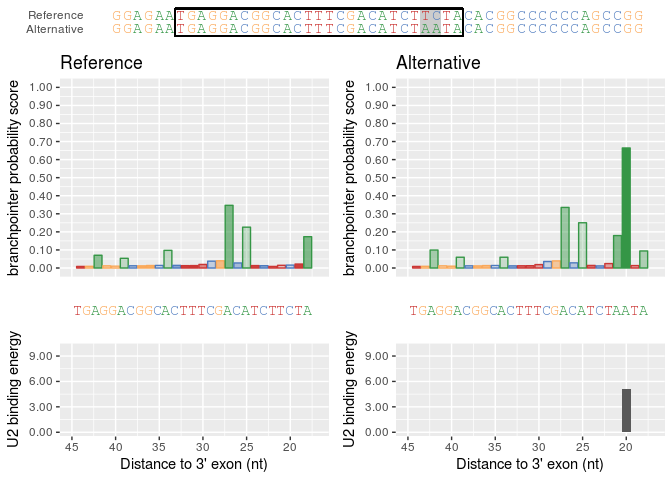

```r
plotBranchpointWindow("99667",
                      branchpointPredictionsIndel,
                      probabilityCutoff = 0.52,
                      plotMutated = TRUE,
                      plotStructure = FALSE,
                      exons = exons)
```

Creation of branchpoint by deletion

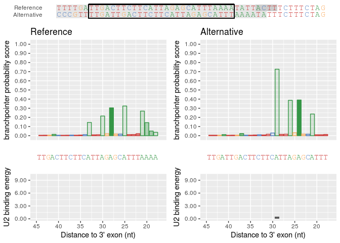

```r
plotBranchpointWindow("406041",
                      branchpointPredictionsIndel,
                      probabilityCutoff = 0.52,
                      plotMutated = TRUE,
                      plotStructure = FALSE,
                      exons = exons)
```

Deletion of branchpoint by insertion

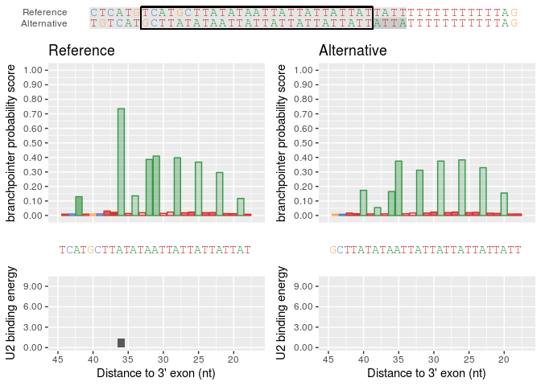

```r
plotBranchpointWindow("389807",
                      branchpointPredictionsIndel,
                      probabilityCutoff = 0.52,
                      plotMutated = TRUE,
                      plotStructure = FALSE,
                      exons = exons)
```

# 6 Performance

Branchpointer is vectorised where possible to decrease run times.

When reading in SNP queries, a prefiltering step can be applied by setting `filter=TRUE`. This step adds less than 10 seconds to `readQueryFile()`, and can reduce run times when the locations of SNPs are unknown [Figure 1].

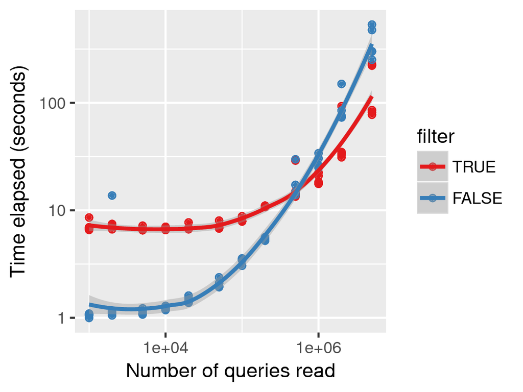

`predictBranchpoints()` is the rate limiting step, taking ~55 seconds per 100 region queries. This can be lowered using parallelisation by setting `useParallel=TRUE` and specifying the number of cores [Figure 2].

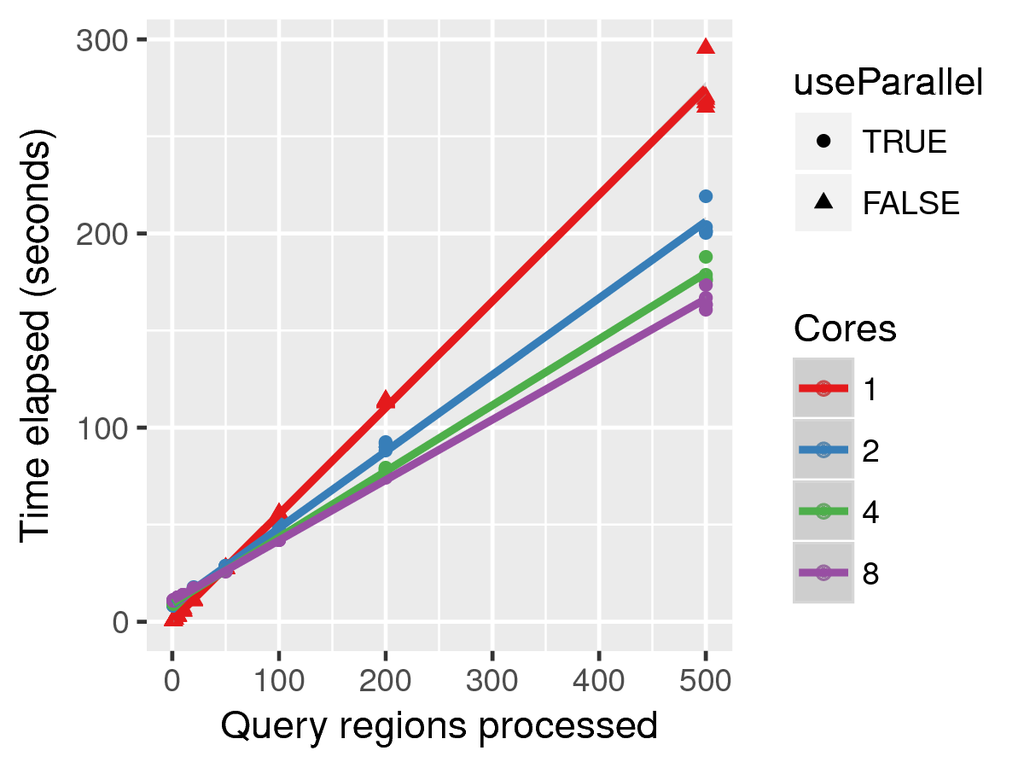

## 6.1 Example run times

```r
# Step times for annotating branchpoints in introns:
gtfToExons()
# user  system elapsed
# 41.385   3.848  47.096

# Set 1. 294 lincRNA introns on chr22:
makeBranchpointWindowForExons()
# user  system elapsed
# 0.196   0.024   0.226
predictBranchpoints()
# user  system elapsed
# 208.934   4.157 225.849

# Set 2. 3693 protein coding exons on chr22:
makeBranchpointWindowForExons()
# user  system elapsed
# 0.245   0.013   0.261
predictBranchpoints()
# user   system  elapsed
# 2332.519   38.266 2482.032

# Step times for annotating branchpoints with SNPs:
# 29899 GWAS SNPS
readQueryFile(filter = TRUE)
# user  system elapsed
# 5.997   1.608   7.773
readQueryFile(filter = FALSE)
# user  system elapsed
# 1.744   0.427   2.339

# 298 filtered SNPS
predictBranchpoints()
# user  system elapsed
# 172.495   2.485 181.876

predictionsToSummary()
# user  system elapsed
# 0.057   0.003   0.061
```

Example scripts used to test times are found in inst/scripts, and were run on a 2.4GHz Macbook Pro with 8GB RAM